# Previsão do MAPE em modelos de metano entérico

IME0546 — Tópicos em Matemática Aplicada · Rede Global de Nutrição Animal (treino)

Relatório consolidado das fases 01–05

08/09/2026

Este documento reúne a exploração, as hipóteses do case e o desenho de modelagem sobre o **conjunto de treino** (`dados_treino.xlsx`). O arquivo de teste permanece **lacrado**: nenhuma decisão abaixo usa `dados_teste.xlsx`.

O objeto de previsão **não** é a emissão de metano. Para cada animal, cinco modelos empíricos (`Modelo_1` … `Modelo_5`) já tentaram prever essa emissão; o que a planilha registra é o **MAPE** (erro percentual absoluto médio) de cada tentativa. Quanto menor o MAPE, melhor aquele modelo empírico foi naquela observação.

# 1 Problema e recorte

## 1.1 O que o case pede

A base mascarada da Rede Global de Nutrição Animal reúne estudos de confinamento em 16 países. Cinco países tiveram **um estudo inteiro** retirado do treino (Campo Rico, Ilha Verdejante, Terra Nortenha, Monção Dourada, Costa Austral). Esse estudo só existe no teste.

Perguntas do enunciado, a responder **antes** de abrir o teste:

1. Existe um modelo empírico melhor na maioria dos países, ou o campeão muda?
2. Sexo, status metabólico e peso se relacionam com quem erra menos?
3. Qual modelo apostaríamos no estudo oculto de cada um dos cinco países?

Há ainda o horizonte da **competição da disciplina**: um modelo nosso que, para cada linha, preveja o MAPE contínuo. São dois alvos:

| Superfície | Pergunta | Métrica |
| --- | --- | --- |
| Case | Qual dos cinco empíricos errará menos no estudo novo? | Ranking / Top-1 |
| Competição | Qual o valor do MAPE daquela linha? | MAE, RMSE, $R^2$ |

Acertar o número do MAPE não garante acertar **quem** é o melhor dos cinco no mesmo animal. Por isso o relatório trata os dois.

## 1.2 Unidade de análise

Cada linha é o par $(\text{animal}, \text{modelo empírico})$. Os cinco MAPEs do mesmo `ID_Observacao` são **dependentes**. Animais do mesmo `Estudo` compartilham protocolo, dieta e país. Cortar treino/validação por linha (ou só por animal) vaza informação que o teste real não terá: lá some um **estudo completo**.

# 2 Dicionário e integridade

| Coluna | Papel neste trabalho |
| --- | --- |
| `ID_Observacao` | Animal. Cinco linhas compartilham o mesmo ID. |
| `Estudo` | Grupo de validação. **Não** entra como preditor (estudos novos no teste). |
| `Pais_Estudo` | Pode entrar: os cinco países do case **existem** no treino. |
| `Sistema_Producao` | Enunciado: só confinamento nesta base. |
| `Status_Metabolico` | Crescimento, Terminação, Maturo, Crescimento e Terminação. |
| `Sexo_Animal` | Boi, Vaca, Novilho, Novilha, Touro, Não especificado. |
| `Peso_Corporal_kg`, `Consumo_MS_kg` | Covariáveis contínuas do animal. |
| `Fracao_Perda_A`, `Fracao_Perda_B` | Frações de energia perdida como metano. |
| `Modelo` | Qual dos cinco empíricos gerou aquele MAPE. |
| `MAPE` | Alvo. Estritamente positivo no treino. |

Estrutura das colunas usadas na análise (colunas vazias da planilha original foram descartadas na leitura).

| Coluna | Tipo | Nulos | Valores distintos |
| --- | --- | --- | --- |
| ID_Observacao | numeric | 0 | 223 |
| Estudo | character | 0 | 93 |
| Pais_Estudo | character | 0 | 16 |
| Sistema_Producao | character | 0 | 1 |
| Status_Metabolico | character | 0 | 4 |
| Sexo_Animal | character | 0 | 6 |
| Peso_Corporal_kg | numeric | 0 | 127 |
| Consumo_MS_kg | numeric | 0 | 166 |
| Fracao_Perda_A | numeric | 0 | 206 |
| Fracao_Perda_B | numeric | 0 | 206 |
| Modelo | factor | 0 | 5 |
| MAPE | numeric | 0 | 1106 |

Contagens: **1115** linhas, **223** animais, **93** estudos, **16** países, **5** modelos. Mínimo e máximo de linhas por ID: **5** e **5** (sempre 5).

`Sistema_Producao` é só **Confinamento**. A coluna é constante; **não entra no modelo**. Na pecuária real existem outros sistemas (por exemplo terminação a pasto); este recorte foi filtrado de propósito, não é falha de dicionário.

Correlação de `Fracao_Perda_A` com `Fracao_Perda_B`: **1,000000**. No treino as duas séries são indistinguíveis. Na engenharia de features permanece **uma** delas.

# 3 O alvo (MAPE)

## 3.1 Forma da distribuição

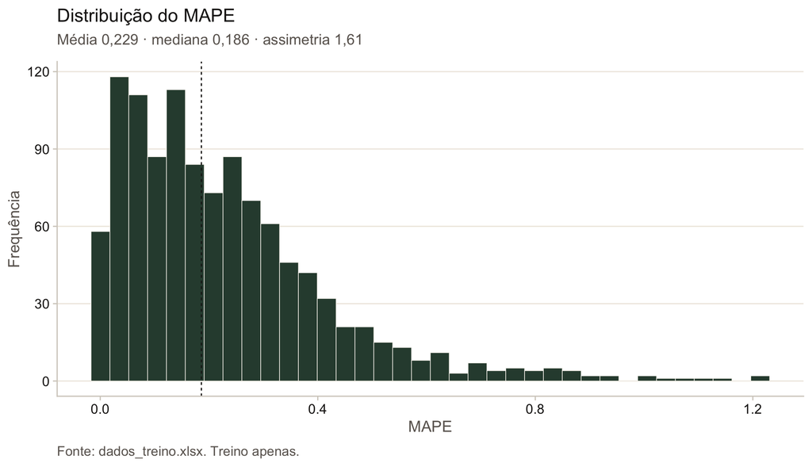

Histograma do MAPE no treino (1.115 linhas). A linha tracejada é a mediana.

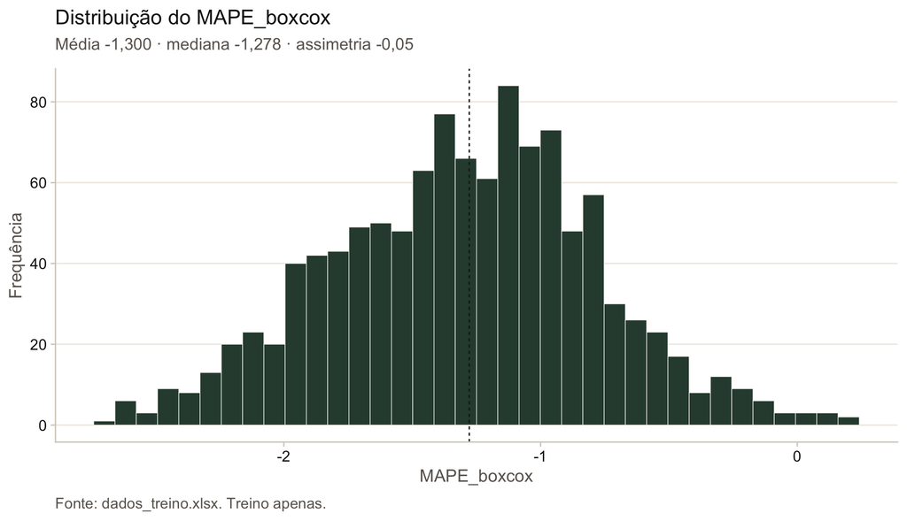

Histograma do MAPE-BOXCOX no treino (1.115 linhas). A linha tracejada é a mediana.

Resumo univariado do MAPE no treino.

| n | media | mediana | desvio | q1 | q3 | minimo | maximo | assimetria | n_nao_positivo |
| --- | --- | --- | --- | --- | --- | --- | --- | --- | --- |
| 1115 | 0,229 | 0,186 | 0,192 | 0,085 | 0,315 | 0,000 | 1,214 | 1,609 | 0 |

Resumo univariado do MAPE_boxcox no treino.

| n | media | mediana | desvio | q1 | q3 | minimo | maximo | assimetria | n_nao_positivo |
| --- | --- | --- | --- | --- | --- | --- | --- | --- | --- |
| 1115 | -1,300 | -1,278 | 0,516 | -1,661 | -0,953 | -2,699 | 0,200 | -0,047 | 1108 |

A média (0,229) está acima da mediana (0,186): cauda direita. O máximo (1,214) ultrapassa 100% de erro percentual. Não há MAPE ≤ 0; $\ln(\text{MAPE})$ é definido, mas qualquer modelo treinado no log tem de **inverter** antes da métrica da competição, que é na escala original.

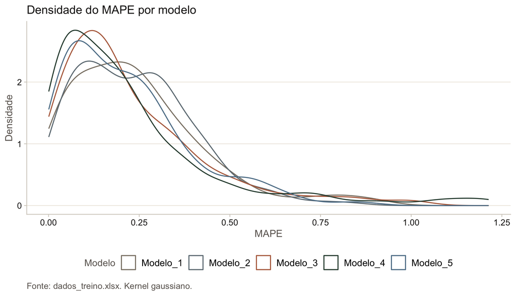

Densidade do MAPE por modelo empírico. A cauda longa é comum aos cinco; o centro de massa não.

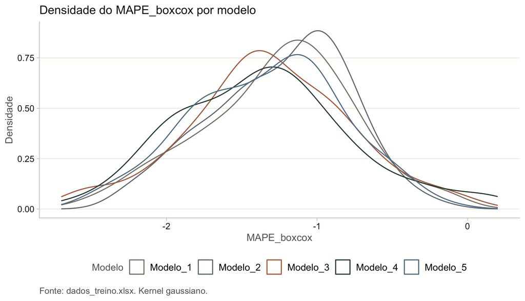

## 3.2 Desempenho global dos cinco modelos empíricos

O **baseline** da metodologia é o modelo com **menor mediana** de MAPE no treino. Por esse critério o campeão é **Modelo_4**. Pela **média**, o menor valor é o de **Modelo_5**: o Modelo_5 sofre menos com extremos, o Modelo_4 ganha no centro da distribuição. A métrica de desempate combinada foi a mediana, mais robusta à cauda.

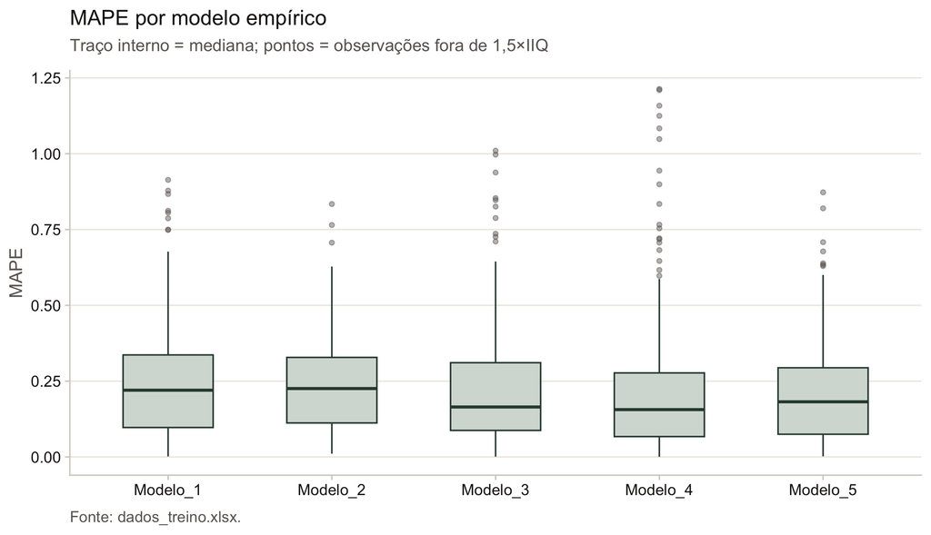

Boxplot do MAPE por modelo empírico (n = 223 por modelo).

MAPE por modelo empírico, ordenado pela mediana.

| Modelo | n | Média | Mediana | Desvio | Q1 | Q3 | Mín. | Máx. |
| --- | --- | --- | --- | --- | --- | --- | --- | --- |
| Modelo_4 | 223 | 0,226 | 0,156 | 0,238 | 0,067 | 0,277 | 0,000 | 1,214 |
| Modelo_3 | 223 | 0,227 | 0,165 | 0,199 | 0,088 | 0,311 | 0,001 | 1,010 |
| Modelo_5 | 223 | 0,214 | 0,182 | 0,170 | 0,075 | 0,294 | 0,002 | 0,873 |
| Modelo_1 | 223 | 0,242 | 0,220 | 0,184 | 0,097 | 0,336 | 0,002 | 0,914 |
| Modelo_2 | 223 | 0,238 | 0,226 | 0,159 | 0,112 | 0,328 | 0,011 | 0,834 |

Como os cinco MAPEs são do **mesmo** animal, o teste adequado de diferença entre modelos é o de Friedman (blocos = `ID_Observacao`): estatística $\chi^2 = 33,28$, gl = 4, $p$ = < 0,001. Rejeita-se a hipótese de que os cinco tenham a mesma distribuição de MAPE.

## 3.3 Quem vence animal a animal (Top-1 observado)

Para cada ID, o “vencedor” é o modelo de menor MAPE **real**. Empates foram quebrados pela primeira ocorrência (`slice_min(..., with_ties = FALSE)`); no treino o total de vitórias soma 223, ou seja, não houve empate residual nesse critério.

Quantas vezes cada modelo empírico tem o menor MAPE no animal.

| Modelo | Vitórias | Fração dos animais |
| --- | --- | --- |
| Modelo_4 | 89 | 39,9% |
| Modelo_3 | 38 | 17,0% |
| Modelo_2 | 35 | 15,7% |
| Modelo_5 | 35 | 15,7% |
| Modelo_1 | 26 | 11,7% |

O Modelo_4 vence em 39,9% dos animais — é o mais frequente, mas **não** é maioria absoluta. Há nicho real para os outros quatro.

# 4 Covariáveis do animal

## 4.1 Contínuas (um registro por animal)

Resumo das covariáveis contínuas (223 animais).

| Variável | n | Média | Mediana | Desvio | Mín. | Máx. |
| --- | --- | --- | --- | --- | --- | --- |
| Consumo_MS_kg | 223 | 8,363 | 8,600 | 2,698 | 2,750 | 20,000 |
| Fracao_Perda_A | 223 | 0,021 | 0,020 | 0,006 | 0,009 | 0,047 |
| Fracao_Perda_B | 223 | 0,021 | 0,020 | 0,006 | 0,009 | 0,047 |
| Peso_Corporal_kg | 223 | 421,755 | 397,000 | 133,418 | 98,000 | 725,000 |

Peso e consumo correlacionam entre si (0,53), o que é esperado zootecnicamente. Com o MAPE, as correlações de Pearson são fracas: peso -0,084, consumo 0,009, fração A 0,107. Sozinhas, essas variáveis não “explicam” o erro; ainda assim podem importar **em interação com o modelo empírico**.

Correlação de Pearson (linhas do treino, n = 1.115).

|  | MAPE | Peso_Corporal_kg | Consumo_MS_kg | Fracao_Perda_A | Fracao_Perda_B |
| --- | --- | --- | --- | --- | --- |
| MAPE | 1,000 | -0,084 | 0,009 | 0,107 | 0,107 |
| Peso_Corporal_kg | -0,084 | 1,000 | 0,526 | -0,453 | -0,453 |
| Consumo_MS_kg | 0,009 | 0,526 | 1,000 | 0,457 | 0,457 |
| Fracao_Perda_A | 0,107 | -0,453 | 0,457 | 1,000 | 1,000 |
| Fracao_Perda_B | 0,107 | -0,453 | 0,457 | 1,000 | 1,000 |

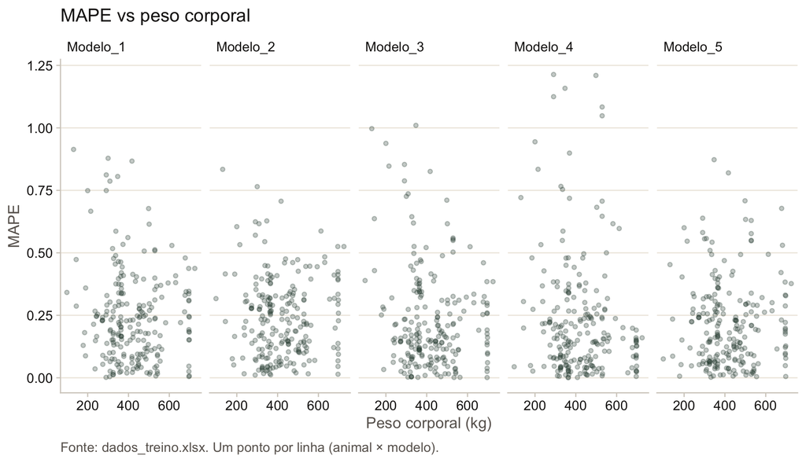

MAPE contra peso corporal, por modelo. A nuvem é dispersa: não há reta óbvia.

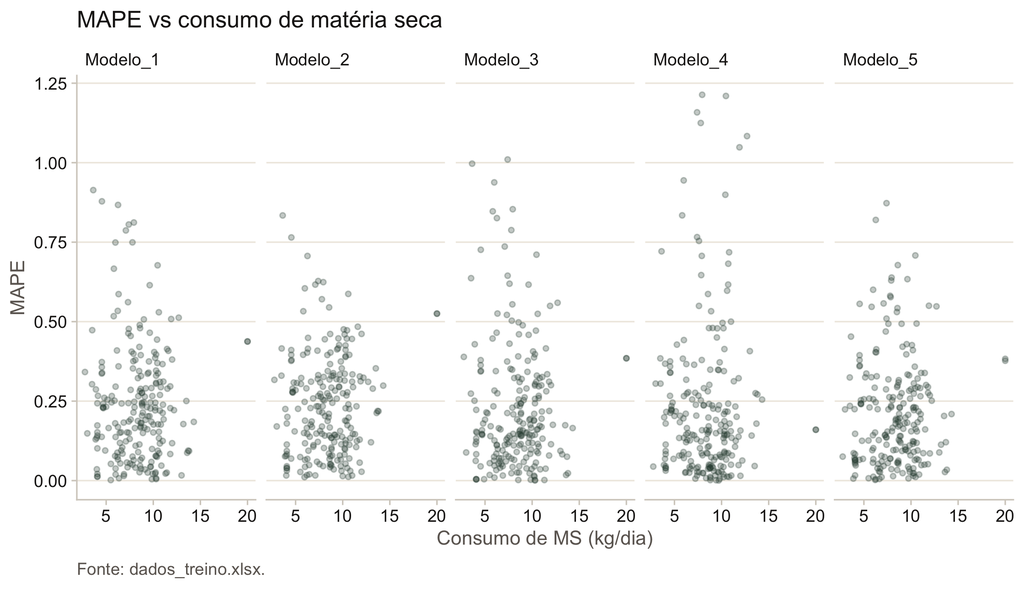

MAPE contra consumo de matéria seca, por modelo.

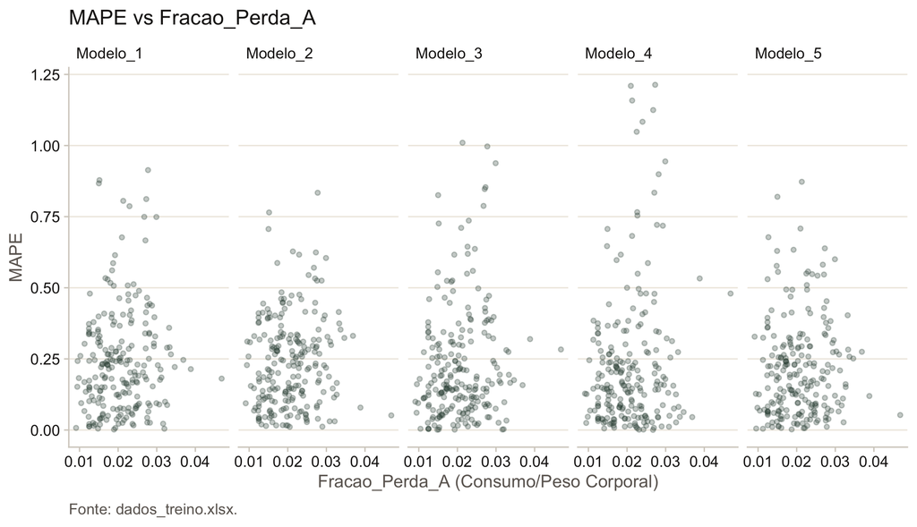

MAPE contra Fracao_Perda_A, por modelo.

A taxa `Consumo_MS_kg / Peso_Corporal_kg` entra depois como feature zootécnica (consumo relativo ao peso).

## 4.2 Status metabólico

Kruskal–Wallis do MAPE entre status (ignorando o pareamento por modelo): $p$ = 0,001. O nível de erro não é o mesmo nas fases produtivas, mas o que o case pergunta é se o **vencedor** muda.

Modelo de menor mediana de MAPE em cada status metabólico.

| Status | Vencedor (mediana) | n | Média | Mediana |
| --- | --- | --- | --- | --- |
| Crescimento | Modelo_3 | 113 | 0,242 | 0,158 |
| Crescimento e Terminação | Modelo_3 | 8 | 0,075 | 0,066 |
| Maturo | Modelo_3 | 17 | 0,141 | 0,135 |
| Terminação | Modelo_4 | 85 | 0,210 | 0,142 |

MAPE completo: status × modelo.

| Status | Modelo | n | Média | Mediana |
| --- | --- | --- | --- | --- |
| Crescimento | Modelo_3 | 113 | 0,242 | 0,158 |
| Crescimento | Modelo_5 | 113 | 0,217 | 0,163 |
| Crescimento | Modelo_4 | 113 | 0,256 | 0,180 |
| Crescimento | Modelo_1 | 113 | 0,248 | 0,214 |
| Crescimento | Modelo_2 | 113 | 0,250 | 0,234 |
| Crescimento e Terminação | Modelo_3 | 8 | 0,075 | 0,066 |
| Crescimento e Terminação | Modelo_5 | 8 | 0,099 | 0,091 |
| Crescimento e Terminação | Modelo_1 | 8 | 0,108 | 0,097 |
| Crescimento e Terminação | Modelo_4 | 8 | 0,161 | 0,183 |
| Crescimento e Terminação | Modelo_2 | 8 | 0,215 | 0,207 |
| Maturo | Modelo_3 | 17 | 0,141 | 0,135 |
| Maturo | Modelo_5 | 17 | 0,161 | 0,135 |
| Maturo | Modelo_4 | 17 | 0,146 | 0,157 |
| Maturo | Modelo_1 | 17 | 0,187 | 0,185 |
| Maturo | Modelo_2 | 17 | 0,241 | 0,266 |
| Terminação | Modelo_4 | 85 | 0,210 | 0,142 |
| Terminação | Modelo_2 | 85 | 0,224 | 0,174 |
| Terminação | Modelo_3 | 85 | 0,237 | 0,210 |
| Terminação | Modelo_5 | 85 | 0,229 | 0,210 |
| Terminação | Modelo_1 | 85 | 0,257 | 0,241 |

Crescimento (n = 113 animais) favorece o **Modelo_3** na mediana. Terminação favorece o **Modelo_4**. “Crescimento e Terminação” e Maturo têm n pequeno (8 e 17 animais): o vencedor local é instável.

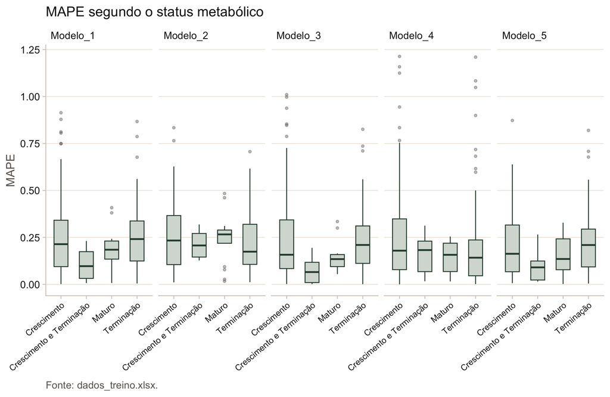

Distribuição do MAPE por status, um painel por modelo empírico.

## 4.3 Sexo

Kruskal–Wallis: $p$ = < 0,001.

Tamanho amostral por sexo (um registro por animal).

| Sexo | Animais |
| --- | --- |
| Boi | 136 |
| Novilho | 44 |
| Novilha | 22 |
| Vaca | 13 |
| Não especificado | 4 |
| Touro | 4 |

Boi concentra 136/223 animais. Touro e Não especificado têm **4** animais cada: qualquer “nicho” nessas células é ruído.

Modelo de menor mediana de MAPE em cada sexo.

| Sexo | Vencedor (mediana) | n linhas | Média | Mediana |
| --- | --- | --- | --- | --- |
| Boi | Modelo_4 | 136 | 0,249 | 0,148 |
| Novilha | Modelo_4 | 22 | 0,172 | 0,159 |
| Novilho | Modelo_5 | 44 | 0,173 | 0,124 |
| Não especificado | Modelo_3 | 4 | 0,149 | 0,146 |
| Touro | Modelo_4 | 4 | 0,081 | 0,041 |
| Vaca | Modelo_4 | 13 | 0,140 | 0,050 |

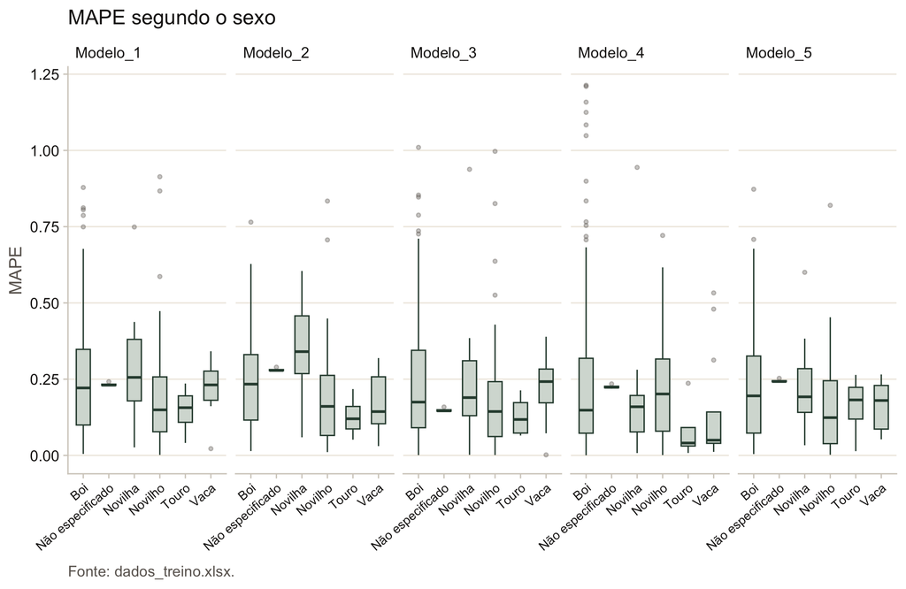

MAPE por sexo do animal, facetas por modelo empírico.

Novilho puxa o **Modelo_5**; Boi, Vaca e Novilha, o **Modelo_4**. Isso reforça a necessidade de interação `Modelo ×` características, e também o risco de overfit se o encoding de sexo for ingênuo nas classes raras.

# 5 Geografia: países e estudos

Kruskal–Wallis do MAPE entre países: $p$ = < 0,001. O nível de erro **não** é o mesmo em todo lugar.

## 5.1 Tamanho amostral por país

Grandvale sozinho tem **90** dos 223 animais (cerca de 40,4%). O campeão global é, em boa parte, o campeão de Grandvale. Países com 2–3 animais não sustentam uma aposta estável.

Cobertura do treino por país. Os cinco do case não são os menores.

| País | Estudos no treino | Animais | Linhas |
| --- | --- | --- | --- |
| Grandvale | 33 | 90 | 450 |
| Campo Rico | 14 | 25 | 125 |
| Reino Litoral | 4 | 17 | 85 |
| Ilha Verdejante | 9 | 16 | 80 |
| Monção Dourada | 5 | 12 | 60 |
| Planalto Sol | 4 | 12 | 60 |
| Terra Nortenha | 6 | 12 | 60 |
| Costa Austral | 4 | 10 | 50 |
| Arquipélago Oriente | 3 | 7 | 35 |
| Vale do Indus Novo | 4 | 6 | 30 |
| Península Matina | 2 | 5 | 25 |
| Ilhota Central | 1 | 3 | 15 |
| Alpes Neutros | 1 | 2 | 10 |
| Baixo Reino | 1 | 2 | 10 |
| Império Central | 1 | 2 | 10 |
| Terra do Galo | 1 | 2 | 10 |

## 5.2 Mediana país × modelo

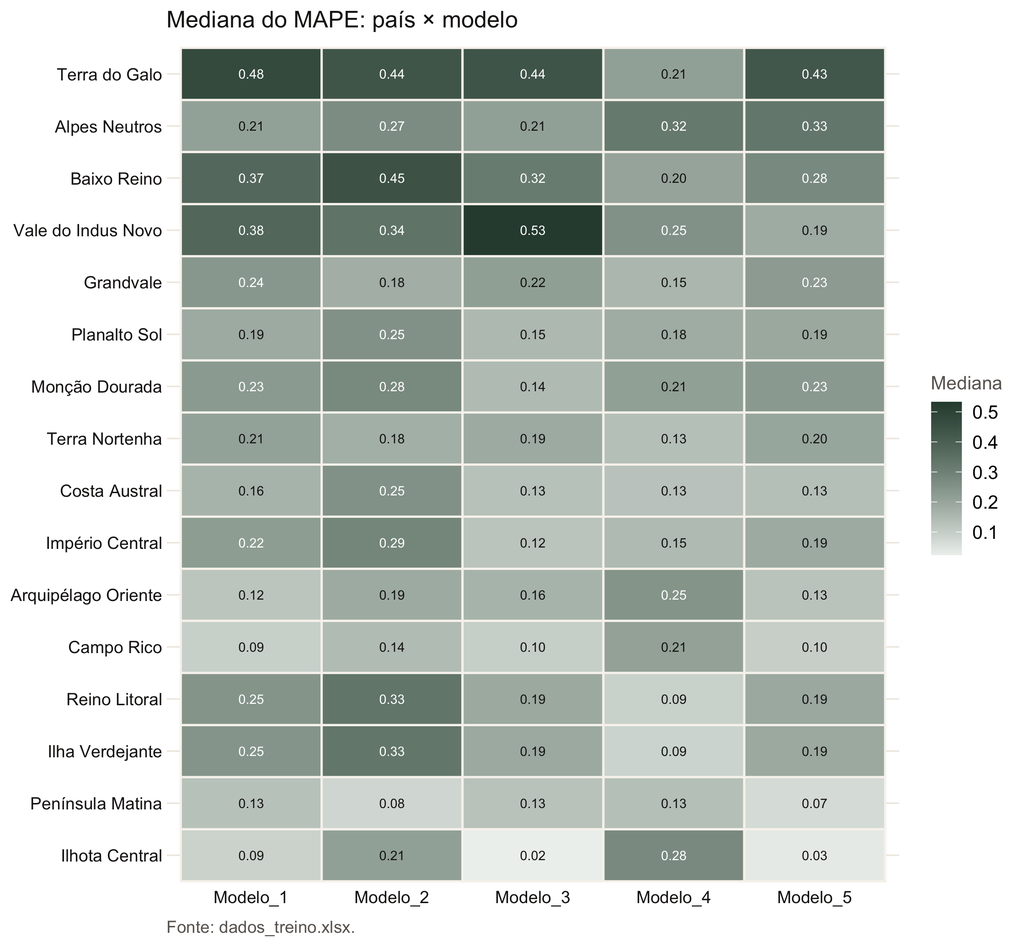

Mediana do MAPE por país e modelo. Células escuras = erro maior. Países ordenados pela melhor mediana entre os cinco.

Vencedor por mediana em cada país (treino). Estudos e animais restantes naquele país.

| País | Vencedor | Mediana | Estudos | Animais |
| --- | --- | --- | --- | --- |
| Alpes Neutros | Modelo_1 | 0,210 | 1 | 2 |
| Arquipélago Oriente | Modelo_1 | 0,118 | 3 | 7 |
| Baixo Reino | Modelo_4 | 0,204 | 1 | 2 |
| Campo Rico | Modelo_1 | 0,094 | 14 | 25 |
| Costa Austral | Modelo_4 | 0,127 | 4 | 10 |
| Grandvale | Modelo_4 | 0,155 | 33 | 90 |
| Ilha Verdejante | Modelo_4 | 0,087 | 9 | 16 |
| Ilhota Central | Modelo_3 | 0,023 | 1 | 3 |
| Império Central | Modelo_3 | 0,123 | 1 | 2 |
| Monção Dourada | Modelo_3 | 0,145 | 5 | 12 |
| Península Matina | Modelo_5 | 0,067 | 2 | 5 |
| Planalto Sol | Modelo_3 | 0,151 | 4 | 12 |
| Reino Litoral | Modelo_4 | 0,091 | 4 | 17 |
| Terra Nortenha | Modelo_4 | 0,134 | 6 | 12 |
| Terra do Galo | Modelo_4 | 0,214 | 1 | 2 |
| Vale do Indus Novo | Modelo_5 | 0,185 | 4 | 6 |

O vencedor local **não** é único: aparecem Modelo_1, 3, 4 e 5. A resposta à primeira pergunta do case é: **o campeão muda de país para país**.

## 5.3 Fração de vitórias (Top-1) nos cinco países do case

A mediana e o Top-1 podem discordar. Campo Rico é o exemplo: a mediana favorece o Modelo_1, mas a fração de vitórias favorece o Modelo_5.

Top-1 observado nos animais do treino, só nos cinco países com estudo oculto.

| País | Modelo | Vitórias | Fração |
| --- | --- | --- | --- |
| Campo Rico | Modelo_1 | 5 | 20% |
| Campo Rico | Modelo_2 | 6 | 24% |
| Campo Rico | Modelo_3 | 4 | 16% |
| Campo Rico | Modelo_4 | 2 | 8% |
| Campo Rico | Modelo_5 | 8 | 32% |
| Costa Austral | Modelo_1 | 1 | 10% |
| Costa Austral | Modelo_2 | 0 | 0% |
| Costa Austral | Modelo_3 | 3 | 30% |
| Costa Austral | Modelo_4 | 5 | 50% |
| Costa Austral | Modelo_5 | 1 | 10% |
| Ilha Verdejante | Modelo_1 | 1 | 6% |
| Ilha Verdejante | Modelo_2 | 0 | 0% |
| Ilha Verdejante | Modelo_3 | 1 | 6% |
| Ilha Verdejante | Modelo_4 | 13 | 81% |
| Ilha Verdejante | Modelo_5 | 1 | 6% |
| Monção Dourada | Modelo_1 | 0 | 0% |
| Monção Dourada | Modelo_2 | 0 | 0% |
| Monção Dourada | Modelo_3 | 7 | 58% |
| Monção Dourada | Modelo_4 | 3 | 25% |
| Monção Dourada | Modelo_5 | 2 | 17% |
| Terra Nortenha | Modelo_1 | 0 | 0% |
| Terra Nortenha | Modelo_2 | 0 | 0% |
| Terra Nortenha | Modelo_3 | 2 | 17% |
| Terra Nortenha | Modelo_4 | 8 | 67% |
| Terra Nortenha | Modelo_5 | 2 | 17% |

MAPE médio e mediano nos cinco países (estudos que restaram no treino).

| País | Modelo | n | Média | Mediana |
| --- | --- | --- | --- | --- |
| Campo Rico | Modelo_1 | 25 | 0,150 | 0,094 |
| Campo Rico | Modelo_5 | 25 | 0,134 | 0,096 |
| Campo Rico | Modelo_3 | 25 | 0,152 | 0,098 |
| Campo Rico | Modelo_2 | 25 | 0,175 | 0,144 |
| Campo Rico | Modelo_4 | 25 | 0,236 | 0,209 |
| Costa Austral | Modelo_4 | 10 | 0,141 | 0,127 |
| Costa Austral | Modelo_3 | 10 | 0,160 | 0,128 |
| Costa Austral | Modelo_5 | 10 | 0,179 | 0,134 |
| Costa Austral | Modelo_1 | 10 | 0,185 | 0,165 |
| Costa Austral | Modelo_2 | 10 | 0,251 | 0,252 |
| Ilha Verdejante | Modelo_4 | 16 | 0,113 | 0,087 |
| Ilha Verdejante | Modelo_3 | 16 | 0,203 | 0,190 |
| Ilha Verdejante | Modelo_5 | 16 | 0,210 | 0,190 |
| Ilha Verdejante | Modelo_1 | 16 | 0,257 | 0,245 |
| Ilha Verdejante | Modelo_2 | 16 | 0,310 | 0,331 |
| Monção Dourada | Modelo_3 | 12 | 0,161 | 0,145 |
| Monção Dourada | Modelo_4 | 12 | 0,190 | 0,215 |
| Monção Dourada | Modelo_1 | 12 | 0,201 | 0,229 |
| Monção Dourada | Modelo_5 | 12 | 0,180 | 0,232 |
| Monção Dourada | Modelo_2 | 12 | 0,218 | 0,277 |
| Terra Nortenha | Modelo_4 | 12 | 0,147 | 0,134 |
| Terra Nortenha | Modelo_2 | 12 | 0,197 | 0,175 |
| Terra Nortenha | Modelo_3 | 12 | 0,209 | 0,187 |
| Terra Nortenha | Modelo_5 | 12 | 0,218 | 0,200 |
| Terra Nortenha | Modelo_1 | 12 | 0,232 | 0,209 |

# 6 Variância entre estudos

Se o MAPE fosse i.i.d. entre linhas, K-fold simples bastaria. A ANOVA de um fator `MAPE ~ Estudo` decompõe a soma de quadrados:

ANOVA one-way do MAPE em Estudo.

| Fonte | gl | Soma de quadrados | Fração da SQ |
| --- | --- | --- | --- |
| Estudo | 92 | 23,525 | 57,4% |
| Residual (dentro do estudo) | 1022 | 17,469 | 42,6% |

O ICC (método dos momentos, desbalanceado) usa o $n_0$ de Searle:

$$n_0 = \frac{N - \sum_i n_i^2 / N}{k - 1}, \quad
\hat\sigma^2_b = \max\bigl(0, (MS_E - MS_R)/n_0\bigr), \quad
\widehat{\mathrm{ICC}} = \hat\sigma^2_b / (\hat\sigma^2_b +
\hat\sigma^2_w).$$

Aqui $k = 93$ estudos, $n_0 \approx 11,94$, $\hat\sigma^2_b = 0,0200$, $\hat\sigma^2_w = 0,0171$, **ICC = 0,539**. Cerca de metade da variância do MAPE está **entre estudos**. Por isso a validação da competição tem de ser `GroupKFold` / leave-one-study-out, e `Estudo` não pode ser dummy no preditor.

Tamanho dos estudos no treino: mínimo 5 linhas, mediana 10, máximo 55 (sempre múltiplo de 5).

# 7 Engenharia de features (fase 03)

# 8 Validação e modelos (fases 04–05)

## 8.1 Protocolo

O seletor de ML substitui “ficar com o campeão do fold” quando o Top-1 no protocolo que imita o teste (LOSO dos cinco países) é **estritamente maior**. Essa regra **foi atendida** pelo Ridge.

Média das métricas entre folds (saída de 04_metricas_resumo.csv).

| protocolo | modelo | n_folds | mape | mae | rmse | r2 | top1 | top1_sempre_campeao |
| --- | --- | --- | --- | --- | --- | --- | --- | --- |
| GroupKFold | ols_simples__num(Fracao_Perda_A)__cat(Sexo_Animal_Modelo) | 5,000 | 2,869 | 0,139 | 0,194 | -0,077 | 0,315 | 0,266 |
| GroupKFold | ols__num(Fracao_Perda_A)__cat(Sexo_Animal_Modelo) | 5,000 | 2,869 | 0,139 | 0,194 | -0,077 | 0,315 | 0,266 |
| GroupKFold | splines__num(Fracao_Perda_A)__cat(Sexo_Animal_Modelo) | 5,000 | 2,869 | 0,139 | 0,194 | -0,077 | 0,315 | 0,266 |
| GroupKFold | splines__num(Fracao_Perda_A)__cat(Modelo) | 5,000 | 2,918 | 0,140 | 0,194 | -0,080 | 0,315 | 0,266 |
| GroupKFold | splines__num(Peso_Corporal_kg)__cat(Status_Metabolico_Sexo_Animal_Modelo) | 5,000 | 2,918 | 0,143 | 0,197 | -0,117 | 0,315 | 0,266 |
| GroupKFold | ols__num(Fracao_Perda_A)__cat(Modelo) | 5,000 | 2,919 | 0,140 | 0,194 | -0,083 | 0,315 | 0,266 |
| GroupKFold | ols_simples__num(Fracao_Perda_A)__cat(Modelo) | 5,000 | 2,919 | 0,140 | 0,194 | -0,083 | 0,315 | 0,266 |
| GroupKFold | splines__num(Peso_Corporal_kg)__cat(Sexo_Animal_Modelo) | 5,000 | 2,923 | 0,141 | 0,196 | -0,099 | 0,315 | 0,266 |
| GroupKFold | splines__num(Fracao_Perda_A)__cat(Status_Metabolico_Sexo_Animal_Modelo) | 5,000 | 2,926 | 0,142 | 0,196 | -0,105 | 0,315 | 0,266 |
| GroupKFold | ols_simples__num(Peso_Corporal_kg)__cat(Sexo_Animal_Modelo) | 5,000 | 2,926 | 0,140 | 0,195 | -0,091 | 0,315 | 0,266 |
| GroupKFold | ols__num(Peso_Corporal_kg)__cat(Sexo_Animal_Modelo) | 5,000 | 2,926 | 0,140 | 0,195 | -0,091 | 0,315 | 0,266 |
| GroupKFold | ols_simples__num(Peso_Corporal_kg)__cat(Status_Metabolico_Sexo_Animal_Modelo) | 5,000 | 2,929 | 0,142 | 0,196 | -0,108 | 0,315 | 0,266 |
| GroupKFold | ols__num(Peso_Corporal_kg)__cat(Status_Metabolico_Sexo_Animal_Modelo) | 5,000 | 2,929 | 0,142 | 0,196 | -0,108 | 0,315 | 0,266 |
| GroupKFold | ols__num(Fracao_Perda_A)__cat(Status_Metabolico_Sexo_Animal_Modelo) | 5,000 | 2,930 | 0,142 | 0,196 | -0,108 | 0,315 | 0,266 |
| GroupKFold | ols_simples__num(Fracao_Perda_A)__cat(Status_Metabolico_Sexo_Animal_Modelo) | 5,000 | 2,930 | 0,142 | 0,196 | -0,108 | 0,315 | 0,266 |
| GroupKFold | splines__num(Consumo_MS_kg_Fracao_Perda_A)__cat(Sexo_Animal_Modelo) | 5,000 | 2,944 | 0,141 | 0,195 | -0,095 | 0,315 | 0,266 |
| GroupKFold | splines_simples__num(Fracao_Perda_A)__cat(Sexo_Animal_Modelo) | 5,000 | 2,944 | 0,141 | 0,195 | -0,097 | 0,315 | 0,266 |
| GroupKFold | ols_simples__num(Consumo_MS_kg_Fracao_Perda_A)__cat(Sexo_Animal_Modelo) | 5,000 | 2,948 | 0,141 | 0,195 | -0,096 | 0,315 | 0,266 |
| GroupKFold | ols__num(Consumo_MS_kg_Fracao_Perda_A)__cat(Sexo_Animal_Modelo) | 5,000 | 2,948 | 0,141 | 0,195 | -0,096 | 0,315 | 0,266 |
| GroupKFold | ols__num(Fracao_Perda_A)__cat(Sexo_Animal) | 5,000 | 2,952 | 0,140 | 0,194 | -0,076 | 0,117 | 0,266 |
| GroupKFold | ols_simples__num(Fracao_Perda_A)__cat(Sexo_Animal) | 5,000 | 2,952 | 0,140 | 0,194 | -0,076 | 0,117 | 0,266 |
| GroupKFold | splines__num(Fracao_Perda_A)__cat(Sexo_Animal) | 5,000 | 2,954 | 0,140 | 0,194 | -0,077 | 0,117 | 0,266 |
| GroupKFold | splines__num(Consumo_MS_kg_Fracao_Perda_A)__cat(Status_Metabolico_Sexo_Animal_Modelo) | 5,000 | 2,957 | 0,143 | 0,197 | -0,119 | 0,315 | 0,266 |
| GroupKFold | baseline_mediana_modelo | 5,000 | 2,958 | 0,140 | 0,194 | -0,079 | 0,266 | 0,266 |
| GroupKFold | ols_simples__num(Consumo_MS_kg_Fracao_Perda_A)__cat(Status_Metabolico_Sexo_Animal_Modelo) | 5,000 | 2,961 | 0,143 | 0,197 | -0,119 | 0,315 | 0,266 |
| GroupKFold | ols__num(Consumo_MS_kg_Fracao_Perda_A)__cat(Status_Metabolico_Sexo_Animal_Modelo) | 5,000 | 2,961 | 0,143 | 0,197 | -0,119 | 0,315 | 0,266 |
| GroupKFold | splines__num(Peso_Corporal_kg_Fracao_Perda_A)__cat(Status_Metabolico_Sexo_Animal_Modelo) | 5,000 | 2,962 | 0,144 | 0,197 | -0,125 | 0,315 | 0,266 |
| GroupKFold | splines__num(Consumo_MS_kg)__cat(Sexo_Animal_Modelo) | 5,000 | 2,962 | 0,141 | 0,196 | -0,109 | 0,315 | 0,266 |
| GroupKFold | splines__num(Peso_Corporal_kg_Fracao_Perda_A)__cat(Sexo_Animal_Modelo) | 5,000 | 2,965 | 0,142 | 0,196 | -0,105 | 0,315 | 0,266 |
| GroupKFold | ols_simples__num(Peso_Corporal_kg_Fracao_Perda_A)__cat(Sexo_Animal_Modelo) | 5,000 | 2,965 | 0,141 | 0,195 | -0,096 | 0,315 | 0,266 |

[output cut: 198 more lines]

VIF nos preditores numéricos (diagnóstico de multicolinearidade).

| bloco | variavel | r2_auxiliar | VIF | alerta |
| --- | --- | --- | --- | --- |
| numericos_brutos | Consumo_MS_kg | 0,89 | 8,70 | VIF>=5 |
| numericos_brutos | Peso_Corporal_kg | 0,88 | 8,65 | VIF>=5 |
| numericos_brutos | Fracao_Perda_A | 0,87 | 7,91 | VIF>=5 |

| protocolo | modelo | n_boot | agrupamento | mape | mape_ic95_inf | mape_ic95_sup | mae | mae_ic95_inf | mae_ic95_sup | rmse | rmse_ic95_inf | rmse_ic95_sup |
| --- | --- | --- | --- | --- | --- | --- | --- | --- | --- | --- | --- | --- |
| GroupKFold | splines__num(Fracao_Perda_A)__cat(Sexo_Animal_Modelo) | 1000,000 | Estudo | 2,871 | 0,038 | 15,043 | 0,139 | 0,122 | 0,161 | 0,198 | 0,166 | 0,232 |
| GroupKFold | ols__num(Fracao_Perda_A)__cat(Sexo_Animal_Modelo) | 1000,000 | Estudo | 2,870 | 0,042 | 15,176 | 0,139 | 0,121 | 0,162 | 0,198 | 0,165 | 0,231 |
| GroupKFold | ols_simples__num(Fracao_Perda_A)__cat(Sexo_Animal_Modelo) | 1000,000 | Estudo | 2,870 | 0,042 | 15,176 | 0,139 | 0,121 | 0,161 | 0,198 | 0,165 | 0,231 |
| GroupKFold | splines__num(Fracao_Perda_A)__cat(Modelo) | 1000,000 | Estudo | 2,920 | 0,030 | 17,812 | 0,139 | 0,121 | 0,162 | 0,199 | 0,165 | 0,233 |
| GroupKFold | ols__num(Fracao_Perda_A)__cat(Modelo) | 1000,000 | Estudo | 2,921 | 0,038 | 18,034 | 0,140 | 0,121 | 0,163 | 0,199 | 0,166 | 0,236 |
| GroupKFold | ols_simples__num(Fracao_Perda_A)__cat(Modelo) | 1000,000 | Estudo | 2,921 | 0,038 | 18,034 | 0,140 | 0,121 | 0,162 | 0,199 | 0,165 | 0,235 |
| GroupKFold | baseline_mediana_modelo | 1000,000 | Estudo | 2,960 | 0,030 | 17,290 | 0,140 | 0,123 | 0,161 | 0,198 | 0,166 | 0,232 |
| GroupKFold | splines_simples__num(Peso_Corporal_kg_Consumo_MS_kg)__cat(Sexo_Animal_Modelo) | 1000,000 | Estudo | 3,017 | 0,026 | 16,634 | 0,140 | 0,122 | 0,161 | 0,199 | 0,167 | 0,230 |
| GroupKFold | ols_simples__num(Peso_Corporal_kg)__cat(Sexo_Animal_Modelo) | 1000,000 | Estudo | 2,928 | 0,026 | 18,274 | 0,140 | 0,122 | 0,161 | 0,199 | 0,166 | 0,232 |
| GroupKFold | ols__num(Peso_Corporal_kg)__cat(Sexo_Animal_Modelo) | 1000,000 | Estudo | 2,928 | 0,026 | 18,274 | 0,140 | 0,121 | 0,162 | 0,199 | 0,166 | 0,234 |
| GroupKFold | ols__num(Fracao_Perda_A)__cat(Sexo_Animal) | 1000,000 | Estudo | 2,953 | 0,033 | 14,716 | 0,140 | 0,123 | 0,161 | 0,198 | 0,164 | 0,233 |
| GroupKFold | ols_simples__num(Fracao_Perda_A)__cat(Sexo_Animal) | 1000,000 | Estudo | 2,953 | 0,033 | 14,716 | 0,140 | 0,123 | 0,161 | 0,198 | 0,166 | 0,232 |
| GroupKFold | splines__num(Fracao_Perda_A)__cat(Sexo_Animal) | 1000,000 | Estudo | 2,955 | 0,033 | 14,295 | 0,140 | 0,122 | 0,161 | 0,198 | 0,166 | 0,229 |
| GroupKFold | splines__num(Consumo_MS_kg_Fracao_Perda_A)__cat(Modelo) | 1000,000 | Estudo | 2,988 | 0,030 | 17,862 | 0,141 | 0,123 | 0,163 | 0,200 | 0,168 | 0,235 |
| GroupKFold | splines__num(Consumo_MS_kg)__cat(Sexo_Animal_Modelo) | 1000,000 | Estudo | 2,966 | 0,035 | 18,086 | 0,141 | 0,123 | 0,163 | 0,200 | 0,168 | 0,236 |
| GroupKFold | splines_simples__num(Peso_Corporal_kg_Consumo_MS_kg_Fracao_Perda_A)__cat(Sexo_Animal_Modelo) | 1000,000 | Estudo | 3,038 | 0,025 | 16,684 | 0,141 | 0,122 | 0,161 | 0,199 | 0,167 | 0,232 |
| GroupKFold | ols_simples__num(Consumo_MS_kg)__cat(Sexo_Animal_Modelo) | 1000,000 | Estudo | 2,969 | 0,033 | 18,171 | 0,141 | 0,122 | 0,163 | 0,200 | 0,168 | 0,235 |
| GroupKFold | ols__num(Consumo_MS_kg)__cat(Sexo_Animal_Modelo) | 1000,000 | Estudo | 2,969 | 0,033 | 18,171 | 0,141 | 0,122 | 0,161 | 0,200 | 0,167 | 0,235 |
| GroupKFold | splines__num(Consumo_MS_kg_Fracao_Perda_A)__cat(Sexo_Animal_Modelo) | 1000,000 | Estudo | 2,946 | 0,032 | 17,337 | 0,141 | 0,122 | 0,161 | 0,199 | 0,166 | 0,231 |
| GroupKFold | ols_simples__num(Peso_Corporal_kg_Fracao_Perda_A)__cat(Sexo_Animal_Modelo) | 1000,000 | Estudo | 2,967 | 0,032 | 17,548 | 0,141 | 0,122 | 0,164 | 0,199 | 0,165 | 0,236 |
| GroupKFold | ols__num(Peso_Corporal_kg_Fracao_Perda_A)__cat(Sexo_Animal_Modelo) | 1000,000 | Estudo | 2,967 | 0,032 | 17,548 | 0,141 | 0,123 | 0,161 | 0,199 | 0,167 | 0,232 |
| GroupKFold | ols__num(Consumo_MS_kg_Fracao_Perda_A)__cat(Sexo_Animal_Modelo) | 1000,000 | Estudo | 2,950 | 0,036 | 17,306 | 0,141 | 0,122 | 0,163 | 0,199 | 0,166 | 0,233 |
| GroupKFold | ols_simples__num(Consumo_MS_kg_Fracao_Perda_A)__cat(Sexo_Animal_Modelo) | 1000,000 | Estudo | 2,950 | 0,036 | 17,306 | 0,141 | 0,123 | 0,163 | 0,199 | 0,166 | 0,233 |
| GroupKFold | splines_simples__num(Peso_Corporal_kg_Fracao_Perda_A)__cat(Sexo_Animal_Modelo) | 1000,000 | Estudo | 3,041 | 0,031 | 16,862 | 0,141 | 0,122 | 0,162 | 0,199 | 0,167 | 0,233 |
| GroupKFold | splines_simples__num(Peso_Corporal_kg_Consumo_MS_kg)__cat(Sexo_Animal) | 1000,000 | Estudo | 3,099 | 0,033 | 16,486 | 0,141 | 0,123 | 0,161 | 0,198 | 0,167 | 0,230 |
| GroupKFold | ols_simples__num(Peso_Corporal_kg_Consumo_MS_kg)__cat(Sexo_Animal_Modelo) | 1000,000 | Estudo | 2,972 | 0,040 | 17,467 | 0,141 | 0,124 | 0,162 | 0,199 | 0,170 | 0,231 |
| GroupKFold | ols__num(Peso_Corporal_kg_Consumo_MS_kg)__cat(Sexo_Animal_Modelo) | 1000,000 | Estudo | 2,972 | 0,040 | 17,467 | 0,141 | 0,122 | 0,163 | 0,199 | 0,166 | 0,233 |
| GroupKFold | splines_simples__num(Peso_Corporal_kg)__cat(Sexo_Animal_Modelo) | 1000,000 | Estudo | 3,006 | 0,034 | 16,982 | 0,141 | 0,123 | 0,162 | 0,200 | 0,166 | 0,235 |
| GroupKFold | splines_simples__num(Fracao_Perda_A)__cat(Sexo_Animal_Modelo) | 1000,000 | Estudo | 2,945 | 0,041 | 14,728 | 0,141 | 0,123 | 0,163 | 0,199 | 0,166 | 0,235 |
| GroupKFold | ols_simples__num(Peso_Corporal_kg_Consumo_MS_kg_Fracao_Perda_A)__cat(Sexo_Animal_Modelo) | 1000,000 | Estudo | 2,981 | 0,032 | 17,430 | 0,141 | 0,123 | 0,163 | 0,199 | 0,168 | 0,233 |

[output cut: 84 more lines]

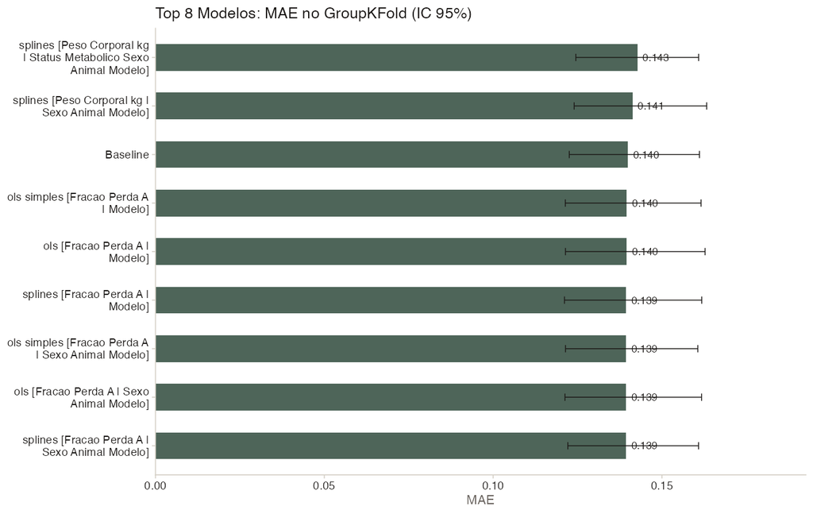

Figuras da validação (script 06_figuras_modelagem.R).

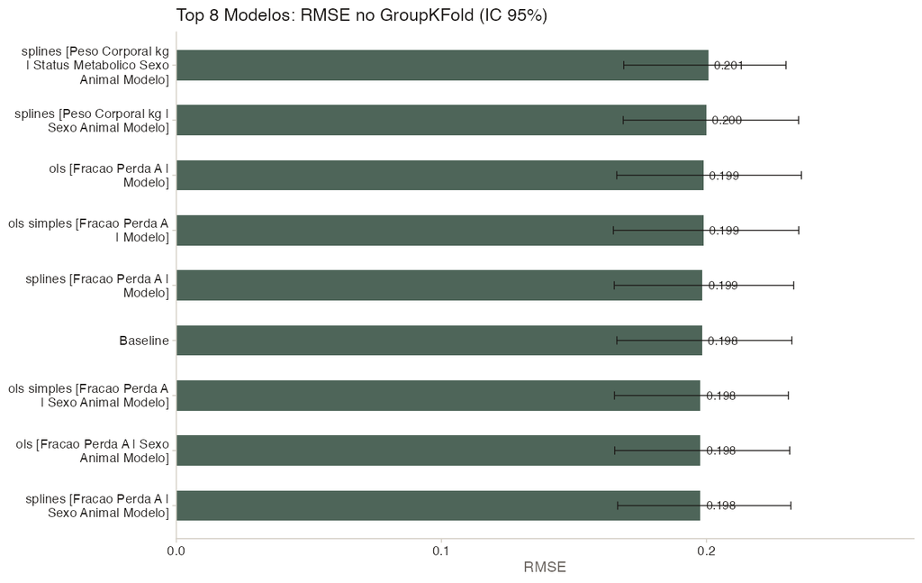

Figuras da validação (script 06_figuras_modelagem.R).

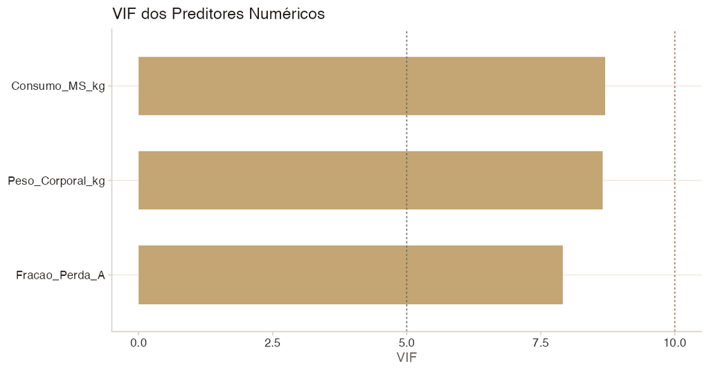

Figuras da validação (script 06_figuras_modelagem.R).

# 9 Apostas do case (teste lacrado)

O teste permanece lacrado: nenhuma aposta abaixo usa `dados_teste.xlsx`.

A mediana local no treino foi, na versão anterior do fluxo, o único critério estável. Com o Ridge em dois estágios (Top-1 0,445 no LOSO), as apostas para o estudo oculto de cada país passam a ter **duas leituras**:

1. **Baseline (conservadora):** menor mediana de MAPE nos estudos **ainda presentes** no treino daquele país. É a tabela abaixo, registrada antes de abrir o teste.
2. **Seletor de ML (recomendado para o ranking):** Ridge em dois estágios, usando peso corporal e fração A (e as categorias do animal) para escolher o empírico de menor MAPE previsto. Esse seletor **não** foi aplicado aos animais do arquivo de teste — o arquivo continua fechado. Ele entra na confrontação oficial, quando o teste for aberto, como desempate baseado nas covariáveis do estudo oculto (não só na história do país).

Apostas registradas antes de abrir dados_teste.xlsx.

| País | Modelo apostado | Mediana no treino | Animais no treino | Estudos no treino |
| --- | --- | --- | --- | --- |
| Campo Rico | Modelo_1 | 0,094 | 25 | 14 |
| Costa Austral | Modelo_4 | 0,127 | 10 | 4 |
| Ilha Verdejante | Modelo_4 | 0,087 | 16 | 9 |
| Monção Dourada | Modelo_3 | 0,145 | 12 | 5 |
| Terra Nortenha | Modelo_4 | 0,134 | 12 | 6 |

- **Campo Rico** (14 estudos, 25 animais no treino). Único dos cinco em que a mediana aponta o **Modelo_1**. O Top-1 observado no treino concentra-se no Modelo_5 (32,0%). Aqui as duas leituras mais provavelmente **divergem**: a tabela conservadora fica com o 1; o Ridge, ao ver peso e fração A do estudo oculto, pode desempatar a favor do 5. Esse é o país em que o seletor mais agrega em relação à mediana.
- **Costa Austral** (4 estudos, 10 animais). **Modelo_4**, alinhado ao global; amostra pequena.
- **Ilha Verdejante** (9 estudos, 16 animais). **Modelo_4**, e o Top-1 local é muito concentrado nesse modelo (81,2%).
- **Monção Dourada** (5 estudos, 12 animais). **Modelo_3**, nicho (não o campeão global); Top-1 também puxa o 3.
- **Terra Nortenha** (6 estudos, 12 animais). **Modelo_4**, coerente com mediana e com vitórias.

A aposta pode falhar se o estudo removido for atípico em relação aos que restaram (composição de sexo/status, protocolo, cauda de MAPE). Isso é exatamente o que o case pede para discutir **depois** de abrir o teste.

# 10 Limitações

- n efetivo ≈ 223 animais e 93 estudos, não 1.115 linhas independentes.
- Desbalanceamento extremo (Grandvale).
- Classes raras de sexo e o status “Crescimento e Terminação”.
- Frações A/B idênticas: ou são a mesma variável mascarada duas vezes, ou o recorte colapsou as duas.
- ICC alto implica que um estudo novo pode deslocar o nível do MAPE de um jeito que covariáveis do animal não capturam (efeito de publicação / protocolo).
- Não olhamos o teste; generalização oficial da competição pode usar outro recorte.

# 11 O que fica amarrado

Reprodução: na pasta do `projeto-rgna.Rproj`, `Rscript` nos scripts 01–03, `python3` nos 04–05, e `rmarkdown::render("relatorio/relatorio-eda.Rmd")`.

[output not shown]